# Analisis Estadistico de Datos

Grupo 05

2025-05-04

# Taller 02

**Multivariada**  
**Maestría en Energías Renovables**  
**Escuela de Ingeniería, Ciencia y Tecnología**  
**Universidad del Rosario**  
**Integrantes:**  
Zahira Itzel González Cleves  
Diego Alejandro Mejía Montañez  
Daniel Felipe Russi Aragón  
Iván Camilo Granados Niño  
Andrés Alfonso Osorio Marulanda

# Desarrollo Taller

```r
library(corrplot)
library(devtools)
library(dplyr)
library(factoextra)
library(FactoMineR)
library(ggExtra)
library(GGally)
library(ggplot2)
library(kableExtra)
library(knitr)
library(MASS)
library(plotly)
library(psych)
library(tidyverse)
library(usethis)
library(writexl)

#carga de datos separados con sep=;
df_pais <- read.table("/Users/aosoriom/Repos/MER_AEDatos/datasets/datos_taller_02.csv",sep=";",header = TRUE)

# Visualiza la tabla de datos de mejor manera y con scroll
# Para tablas pequeñas usar: kable(head(mi_dataframe), caption = "Primeras filas del dataset")
kable(head(df_pais), caption = "Primeras filas del dataset") %>%
  scroll_box(width = "100%", height = "auto")
```

Primeras filas del dataset

| Country | Bunker_fuel_consumption_TBPD | Bunker_residual_fuel_oil_consumption_TBPD | Crude_oil_including_lease_condensate_exports_TBPD | Crude_oil_including_lease_condensate_imports_TBPD | Crude_oil_including_lease_condensate_production_TBPD | Crude_oil_including_lease_condensate_reserves_BB | Distillate_fuel_oil_consumption_TBPD | Distillate_fuel_oil_production_TBPD | Jet_fuel_consumption_TBPD | Jet_fuel_production_TBPD | Kerosene_consumption_TBPD | Kerosene_production_TBPD | Liquefied_petroleum_gases_.LPG._consumption_TBPD | Liquefied_petroleum_gases_.LPG._production_TBPD | Motor_gasoline_consumption_TBPD | Motor_gasoline_production_TBPD | Natural_gas_plant_liquids_production_TBPD | Other_liquids_production_TBPD | Other_refined_products_consumption_TBPD | Other_refined_products_production_TBPD | Petroleum_and_other_liquids_CO2_emissions_MMTCD | Petroleum_and_other_liquids_consumption_TBPD | Petroleum_and_other_liquids_production_TBPD | Refined_petroleum_products_consumption_TBPD | Refined_petroleum_products_production_TBPD | Refinery_processing_gain_TBPD | Residual_fuel_oil_consumption_TBPD | Residual_fuel_oil_production_TBPD | Biomass_and_waste_electricity_installed_capacity_MK | … |
| --- | --- | --- | --- | --- | --- | --- | --- | --- | --- | --- | --- | --- | --- | --- | --- | --- | --- | --- | --- | --- | --- | --- | --- | --- | --- | --- | --- | --- | --- | --- |
| Albania | 0.6 | 0.0 | 19 | 0.9 | 21 | 0.2 | 16 | 1.8 | 0.2 | 0.0 | 0.0 | 0.0 | 3.9 | 0.0 | 2.8 | 0.0 | 0 | 0.0 | 5.4 | 4.7 | 3.7 | 28 | 21 | 28 | 6.6 | 0.0 | 0.1 | 0.1 | 0.0 | … |
| Algeria | 14.0 | 3.8 | 581 | 6.4 | 1420 | 12.0 | 205 | 184.0 | 12.0 | 43.0 | 0.0 | 0.0 | 63.0 | 26.0 | 97.0 | 70.0 | 300 | 0.0 | 35.0 | 213.0 | 53.0 | 416 | 1722 | 416 | 658.0 | 1.8 | 4.0 | 120.0 | 0.0 | … |
| Angola | 12.0 | 6.8 | 1632 | 0.0 | 1742 | 9.1 | 83 | 11.0 | 10.0 | 8.5 | 0.8 | 1.5 | 7.2 | 1.0 | 25.0 | 0.6 | 15 | 0.0 | 9.8 | 6.7 | 21.0 | 159 | 1756 | 159 | 47.0 | -0.7 | 23.0 | 17.0 | 0.0 | … |
| Argentina | 48.0 | 26.0 | 49 | 9.5 | 532 | 2.8 | 232 | 173.0 | 33.0 | 29.0 | 0.5 | 0.3 | 56.0 | 39.0 | 122.0 | 123.0 | 104 | 65.0 | 221.0 | 204.0 | 101.0 | 764 | 713 | 764 | 661.0 | 12.0 | 99.0 | 93.0 | 0.2 | … |
| Australia | 14.0 | 13.0 | 224 | 441.0 | 353 | 1.4 | 433 | 213.0 | 139.0 | 82.0 | 0.6 | 0.1 | 61.0 | 16.0 | 320.0 | 241.0 | 58 | 7.0 | 148.0 | 42.0 | 150.0 | 1126 | 442 | 1126 | 607.0 | 23.0 | 23.0 | 12.0 | 0.8 | … |
| Austria | 0.0 | 0.0 | 0 | 152.0 | 17 | 0.0 | 152 | 81.0 | 14.0 | 13.0 | 0.0 | 0.4 | 3.4 | 2.2 | 38.0 | 43.0 | 1 | 8.9 | 41.0 | 39.0 | 35.0 | 257 | 31 | 257 | 196.0 | 3.7 | 9.4 | 17.0 | 2.1 | … |

```r
summary(df_pais)
```

Country Bunker_fuel_consumption_TBPD Length:111 Min. : 0.00  
Class :character 1st Qu.: 2.70  
Mode :character Median : 8.40  
Mean : 46.01  
3rd Qu.: 32.00  
Max. :924.00  
Bunker_residual_fuel_oil_consumption_TBPD Min. : 0.00  
1st Qu.: 0.00  
Median : 1.70  
Mean : 24.63  
3rd Qu.: 15.50  
Max. :750.00  
Crude_oil_including_lease_condensate_exports_TBPD Min. : 0.0  
1st Qu.: 0.0  
Median : 8.5  
Mean : 361.6  
3rd Qu.: 220.5  
Max. :7120.0  
Crude_oil_including_lease_condensate_imports_TBPD Min. : 0.0  
1st Qu.: 0.0  
Median : 36.0  
Mean : 367.3  
3rd Qu.: 212.0  
Max. :7344.0  
Crude_oil_including_lease_condensate_production_TBPD Min. : 0.0  
1st Qu.: 0.2  
Median : 38.0  
Mean : 702.1  
3rd Qu.: 531.0  
Max. :10107.0  
Crude_oil_including_lease_condensate_reserves_BB Min. : 0.00  
1st Qu.: 0.00  
Median : 0.20  
Mean : 14.82  
3rd Qu.: 3.35  
Max. :298.00  
Distillate_fuel_oil_consumption_TBPD Distillate_fuel_oil_production_TBPD Min. : 4.7 Min. : 0.0  
1st Qu.: 31.0 1st Qu.: 12.5  
Median : 68.0 Median : 57.0  
Mean : 233.6 Mean : 239.9  
3rd Qu.: 214.0 3rd Qu.: 188.5  
Max. :4037.0 Max. :4916.0  
Jet_fuel_consumption_TBPD Jet_fuel_production_TBPD Kerosene_consumption_TBPD Min. : 0.10 Min. : 0.00 Min. : 0.000  
1st Qu.: 2.80 1st Qu.: 1.70 1st Qu.: 0.000  
Median : 11.00 Median : 8.10 Median : 0.500  
Mean : 48.65 Mean : 52.71 Mean : 8.225  
3rd Qu.: 31.00 3rd Qu.: 40.00 3rd Qu.: 2.300  
Max. :1470.00 Max. :1541.00 Max. :298.000  
Kerosene_production_TBPD Liquefied_petroleum_gases_.LPG._consumption_TBPD Min. : 0.00 Min. : 0.20  
1st Qu.: 0.00 1st Qu.: 3.80  
Median : 0.30 Median : 14.00  
Mean : 11.57 Mean : 73.94  
3rd Qu.: 2.40 3rd Qu.: 54.50  
Max. :291.00 Max. :1348.00  
Liquefied_petroleum_gases_.LPG._production_TBPD Min. : 0.00  
1st Qu.: 0.60  
Median : 5.80  
Mean : 35.26  
3rd Qu.: 18.50  
Max. :777.00  
Motor_gasoline_consumption_TBPD Motor_gasoline_production_TBPD Min. : 0.8 Min. : 0.0  
1st Qu.: 13.0 1st Qu.: 5.6  
Median : 33.0 Median : 37.0  
Mean : 214.1 Mean : 211.5  
3rd Qu.: 108.5 3rd Qu.: 106.5  
Max. :8921.0 Max. :9571.0  
Natural_gas_plant_liquids_production_TBPD Other_liquids_production_TBPD Min. : 0.00 Min. : 0.00  
1st Qu.: 0.00 1st Qu.: 0.00  
Median : 0.20 Median : 0.70  
Mean : 85.83 Mean : 31.01  
3rd Qu.: 20.50 3rd Qu.: 8.00  
Max. :3015.00 Max. :1273.00  
Other_refined_products_consumption_TBPD Other_refined_products_production_TBPD Min. : 0.00 Min. : 0.00  
1st Qu.: 5.25 1st Qu.: 4.95  
Median : 22.00 Median : 20.00  
Mean : 170.96 Mean : 148.13  
3rd Qu.: 94.00 3rd Qu.: 110.50  
Max. :3156.00 Max. :2867.00  
Petroleum_and_other_liquids_CO2_emissions_MMTCD Min. : 2.30  
1st Qu.: 9.65  
Median : 26.00  
Mean : 101.04  
3rd Qu.: 94.50  
Max. :2263.00  
Petroleum_and_other_liquids_consumption_TBPD Min. : 15.0  
1st Qu.: 71.5  
Median : 202.0  
Mean : 811.4  
3rd Qu.: 750.0  
Max. :19100.0  
Petroleum_and_other_liquids_production_TBPD Min. : -0.30  
1st Qu.: 11.50  
Median : 64.67  
Mean : 838.75  
3rd Qu.: 569.00  
Max. :14158.00  
Refined_petroleum_products_consumption_TBPD Min. : 15.0  
1st Qu.: 71.5  
Median : 202.0  
Mean : 811.4  
3rd Qu.: 750.0  
Max. :19100.0  
Refined_petroleum_products_production_TBPD Refinery_processing_gain_TBPD Min. : 0.0 Min. : -12.00  
1st Qu.: 39.5 1st Qu.: 0.00  
Median : 172.0 Median : 2.70  
Mean : 777.3 Mean : 19.78  
3rd Qu.: 555.0 3rd Qu.: 8.45  
Max. :19653.0 Max. :1081.00  
Residual_fuel_oil_consumption_TBPD Residual_fuel_oil_production_TBPD Min. : 0.00 Min. : 0.00  
1st Qu.: 4.20 1st Qu.: 6.10  
Median : 17.00 Median : 29.00  
Mean : 61.86 Mean : 78.22  
3rd Qu.: 53.50 3rd Qu.: 77.00  
Max. :788.00 Max. :1577.00  
Biomass_and_waste_electricity_installed_capacity_MK Min. : 0.0000  
1st Qu.: 0.0000  
Median : 0.0000  
Mean : 0.8102  
3rd Qu.: 0.6500  
Max. :16.0000  
Biomass_and_waste_electricity_net_generation_BKWH Min. : 0.000  
1st Qu.: 0.000  
Median : 0.200  
Mean : 3.854  
3rd Qu.: 2.200  
Max. :77.000  
Electricity_distribution_losses_BKWH Electricity_exports_BKWH Min. : 0.10 Min. : 0.000  
1st Qu.: 1.65 1st Qu.: 0.000  
Median : 3.80 Median : 0.600  
Mean : 17.00 Mean : 5.158  
3rd Qu.: 11.00 3rd Qu.: 5.550  
Max. :310.00 Max. :75.000  
Electricity_imports_BKWH Electricity_installed_capacity_MK Min. : 0.000 Min. : 0.40  
1st Qu.: 0.000 1st Qu.: 3.50  
Median : 0.700 Median : 11.00  
Mean : 5.671 Mean : 51.63  
3rd Qu.: 7.550 3rd Qu.: 33.00  
Max. :67.000 Max. :1380.00  
Electricity_net_consumption_BKWH Electricity_net_generation_BKWH Min. : 0.80 Min. : 0.9  
1st Qu.: 9.95 1st Qu.: 12.5  
Median : 37.00 Median : 43.0  
Mean : 181.82 Mean : 198.3  
3rd Qu.: 122.50 3rd Qu.: 136.0  
Max. :5079.00 Max. :5400.0  
Electricity_net_imports_BKWH Fossil_fuels_electricity_installed_capacity_MK Min. :-67.0000 Min. : 0.10  
1st Qu.: -0.7500 1st Qu.: 1.65  
Median : 0.0000 Median : 7.20  
Mean : 0.4961 Mean : 33.41  
3rd Qu.: 0.8500 3rd Qu.: 24.00  
Max. : 53.0000 Max. :924.00  
Fossil_fuels_electricity_net_generation_BKWH Min. : 0.00  
1st Qu.: 4.25  
Median : 21.00  
Mean : 132.58  
3rd Qu.: 80.00  
Max. :3985.00  
Geothermal_electricity_installed_capacity_MK Min. :0.00000  
1st Qu.:0.00000  
Median :0.00000  
Mean :0.09369  
3rd Qu.:0.00000  
Max. :2.50000  
Geothermal_electricity_net_generation_BKWH Min. : 0.0000  
1st Qu.: 0.0000  
Median : 0.0000  
Mean : 0.6108  
3rd Qu.: 0.0000  
Max. :16.0000  
Hydroelectric_pumped_storage_electricity_installed_capacity_MK Min. : 0.000  
1st Qu.: 0.000  
Median : 0.000  
Mean : 1.316  
3rd Qu.: 0.700  
Max. :27.000  
Hydroelectric_pumped_storage_electricity_net_generation_BKWH Min. :-6.2000  
1st Qu.: 0.0000  
Median : 0.0000  
Mean :-0.2532  
3rd Qu.: 0.0000  
Max. : 0.0000  
Hydroelectricity_installed_capacity_MK Hydroelectricity_net_generation_BKWH Min. : 0.000 Min. : 0.00  
1st Qu.: 0.200 1st Qu.: 0.50  
Median : 1.600 Median : 4.70  
Mean : 8.747 Mean : 32.57  
3rd Qu.: 4.550 3rd Qu.: 14.50  
Max. :283.000 Max. :1041.00  
Non.hydro_renewable_electricity_installed_capacity_MK Min. : 0.000  
1st Qu.: 0.000  
Median : 0.500  
Mean : 5.189  
3rd Qu.: 2.400  
Max. :132.000  
Non.hydro_renewable_electricity_net_generation_BKWH Min. : 0.00  
1st Qu.: 0.00  
Median : 1.00  
Mean : 12.21  
3rd Qu.: 7.55  
Max. :304.00  
Nuclear_electricity_installed_capacity_MK Min. : 0.000  
1st Qu.: 0.000  
Median : 0.000  
Mean : 2.943  
3rd Qu.: 0.600  
Max. :99.000  
Nuclear_electricity_net_generation_BKWH Min. : 0.00  
1st Qu.: 0.00  
Median : 0.00  
Mean : 21.22  
3rd Qu.: 3.80  
Max. :797.00  
Renewable_electricity_installed_capacity_MK Min. : 0.00  
1st Qu.: 0.60  
Median : 2.30  
Mean : 13.94  
3rd Qu.: 7.90  
Max. :415.00  
Renewable_electricity_net_generation_BKWH Min. : 0.00  
1st Qu.: 1.50  
Median : 8.30  
Mean : 44.77  
3rd Qu.: 26.50  
Max. :1287.00  
Solar_electricity_installed_capacity_MK Solar_electricity_net_generation_BKWH Min. : 0.000 Min. : 0.000  
1st Qu.: 0.000 1st Qu.: 0.000  
Median : 0.000 Median : 0.000  
Mean : 1.339 Mean : 1.579  
3rd Qu.: 0.300 3rd Qu.: 0.450  
Max. :28.000 Max. :29.000  
Tide_and_wave_electricity_installed_capacity_MK Min. :0.00000  
1st Qu.:0.00000  
Median :0.00000  
Mean :0.00961  
3rd Qu.:0.00000  
Max. :0.40000  
Tide_and_wave_electricity_net_generation_BKWH Min. :0.00000  
1st Qu.:0.00000  
Median :0.00000  
Mean :0.03934  
3rd Qu.:0.00000  
Max. :1.40000  
Wind_electricity_installed_capacity_MK Wind_electricity_net_generation_BKWH Min. : 0.000 Min. : 0.000  
1st Qu.: 0.000 1st Qu.: 0.000  
Median : 0.000 Median : 0.100  
Mean : 2.902 Mean : 6.085  
3rd Qu.: 0.700 3rd Qu.: 1.450  
Max. :97.000 Max. :182.000

## Normal Multivariada

### Pregunta 1 Daniel

$w_1=5$

Encuentre la estimación del vector de medias y la matriz de varianzas y covarianzas para 5 variables de su interés del conjunto de datos.

### Vector de Medias

```r
datos_taller_02 <- df_pais
# Seleccionar las 5 variables de interés
vars_interes <- datos_taller_02[, c(12, 16, 17, 40, 58)]
# Estimación del vector de medias
vector_medias <- colMeans(vars_interes)
print(vector_medias)
```

```
##                    Kerosene_consumption_TBPD
##                                     8.224625
##              Motor_gasoline_consumption_TBPD
##                                   214.132432
##               Motor_gasoline_production_TBPD
##                                   211.467568
## Fossil_fuels_electricity_net_generation_BKWH
##                                   132.584084
##         Wind_electricity_net_generation_BKWH
##                                     6.084685
```

Unidades en las que se miden las variables a estudiar: - TBPD (Thousand Barrels Per Day) - BKWH (Billion Kilowatt-hours)

Se observa que el promedio de consumo de gasolina es muy alto en comparación con otras variables, y que la generación eólica todavía es baja en promedio.

### Matriz de varianzas y covarianzas

```r
# Estimación de la matriz de varianzas y covarianzas
matriz_covarianzas <- cov(vars_interes)
print(matriz_covarianzas)
```

```
##                                              Kerosene_consumption_TBPD
## Kerosene_consumption_TBPD                                   1111.20579
## Motor_gasoline_consumption_TBPD                             3652.59338
## Motor_gasoline_production_TBPD                              4047.14314
## Fossil_fuels_electricity_net_generation_BKWH                4495.08919
## Wind_electricity_net_generation_BKWH                          91.56329
##                                              Motor_gasoline_consumption_TBPD
## Kerosene_consumption_TBPD                                           3652.593
## Motor_gasoline_consumption_TBPD                                   790595.046
## Motor_gasoline_production_TBPD                                    834206.418
## Fossil_fuels_electricity_net_generation_BKWH                      318100.939
## Wind_electricity_net_generation_BKWH                               18042.266
##                                              Motor_gasoline_production_TBPD
## Kerosene_consumption_TBPD                                          4047.143
## Motor_gasoline_consumption_TBPD                                  834206.418
## Motor_gasoline_production_TBPD                                   890035.397
## Fossil_fuels_electricity_net_generation_BKWH                     335168.583
## Wind_electricity_net_generation_BKWH                              19190.037
##                                              Fossil_fuels_electricity_net_generation_BKWH
## Kerosene_consumption_TBPD                                                        4495.089
## Motor_gasoline_consumption_TBPD                                                318100.939
## Motor_gasoline_production_TBPD                                                 335168.583
## Fossil_fuels_electricity_net_generation_BKWH                                   223824.714
## Wind_electricity_net_generation_BKWH                                            10183.494
##                                              Wind_electricity_net_generation_BKWH
## Kerosene_consumption_TBPD                                                91.56329
## Motor_gasoline_consumption_TBPD                                       18042.26614
## Motor_gasoline_production_TBPD                                        19190.03732
## Fossil_fuels_electricity_net_generation_BKWH                          10183.49430
## Wind_electricity_net_generation_BKWH                                    563.17167
```

Las covarianzas (situadas fuera de la diagonal de la matriz) indican cómo dos variables interactuan. Los valores positivos indican relación directa o positiva, los valores negativos indican una relación indirecta o negativa, es decir, mientra una aumenta la otra disminuye. Y por último, si el valor es cero o cercano a cero, indica que las variables no tienen relación.

Podemos concluir que:

A continuación, se muestra la diagonal de la matriz de varianzas y covarianzas, que representan la varianza de cada variable, es decir, qué tanto se dispersan los datos respecto a su media.

```r
# Varianza de cada una de las variables
print (diag(matriz_covarianzas))
```

```
##                    Kerosene_consumption_TBPD
##                                    1111.2058
##              Motor_gasoline_consumption_TBPD
##                                  790595.0460
##               Motor_gasoline_production_TBPD
##                                  890035.3975
## Fossil_fuels_electricity_net_generation_BKWH
##                                  223824.7141
##         Wind_electricity_net_generation_BKWH
##                                     563.1717
```

- La producción y consumo de gasolina tienen altísima varianza, lo que sugiere grandes diferencias entre países.
- La generación eólica tiene baja varianza, lo que indica que la mayoría de los países tienen valores similares (probablemente bajos).
- La generación eléctrica por fósiles también muestra alta varianza, lo cual refleja diferencias estructurales entre países en sus sistemas eléctricos.

## ACP

### Pregunta 2 Daniel

$w_2=5$

Realice un análisis descriptivo univariado y bivariado del conjunto de datos. Considere nuevamente las mismas 5 variables de su interés para este punto.

### Análisis univariado

Resumen estadístico

```r
summary(vars_interes)
```

```
##  Kerosene_consumption_TBPD Motor_gasoline_consumption_TBPD
##  Min.   :  0.000           Min.   :   0.8
##  1st Qu.:  0.000           1st Qu.:  13.0
##  Median :  0.500           Median :  33.0
##  Mean   :  8.225           Mean   : 214.1
##  3rd Qu.:  2.300           3rd Qu.: 108.5
##  Max.   :298.000           Max.   :8921.0
##  Motor_gasoline_production_TBPD Fossil_fuels_electricity_net_generation_BKWH
##  Min.   :   0.0                 Min.   :   0.00
##  1st Qu.:   5.6                 1st Qu.:   4.25
##  Median :  37.0                 Median :  21.00
##  Mean   : 211.5                 Mean   : 132.58
##  3rd Qu.: 106.5                 3rd Qu.:  80.00
##  Max.   :9571.0                 Max.   :3985.00
##  Wind_electricity_net_generation_BKWH
##  Min.   :  0.000
##  1st Qu.:  0.000
##  Median :  0.100
##  Mean   :  6.085
##  3rd Qu.:  1.450
##  Max.   :182.000
```

Desviación estándar para cada variable

```r
sapply(vars_interes, sd, na.rm = TRUE)
```

```
##                    Kerosene_consumption_TBPD
##                                     33.33475
##              Motor_gasoline_consumption_TBPD
##                                    889.15412
##               Motor_gasoline_production_TBPD
##                                    943.41687
## Fossil_fuels_electricity_net_generation_BKWH
##                                    473.10117
##         Wind_electricity_net_generation_BKWH
##                                     23.73124
```

#### Histograma de distribución para cada variable

Histograma de distribución Kerosene_consumption_TBPD

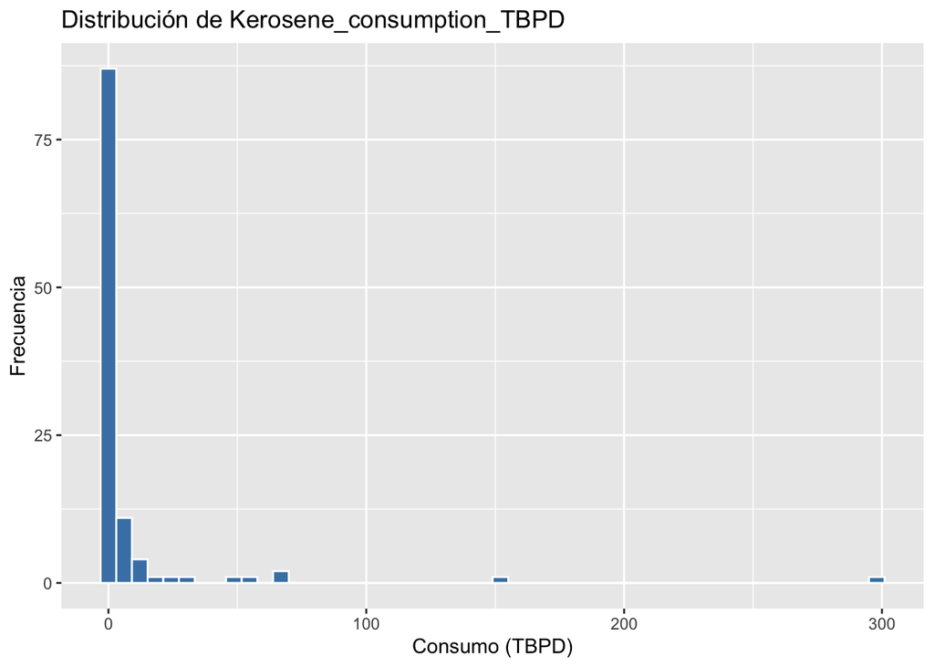

```r
ggplot(vars_interes, aes(x = Kerosene_consumption_TBPD)) +
  geom_histogram(fill = "steelblue", color = "white", bins = 50) +
  labs(title = "Distribución de Kerosene_consumption_TBPD",
       x = "Consumo (TBPD)",
       y = "Frecuencia")
```

Histograma de distribución Motor_gasoline_consumption_TBPD

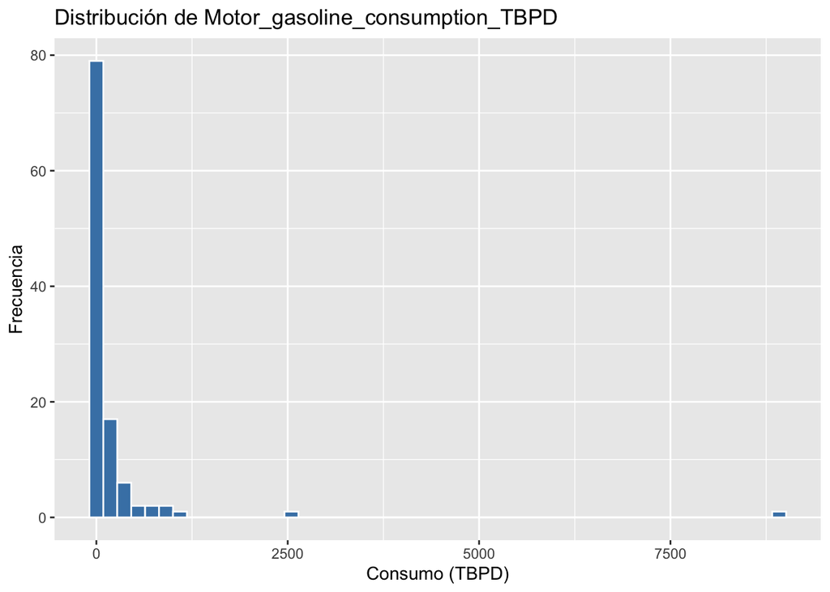

```r
ggplot(vars_interes, aes(x = Motor_gasoline_consumption_TBPD)) +
  geom_histogram(fill = "steelblue", color = "white", bins = 50) +
  labs(title = "Distribución de Motor_gasoline_consumption_TBPD",
       x = "Consumo (TBPD)",
       y = "Frecuencia")
```

Histograma de distribución Motor_gasoline_production_TBPD

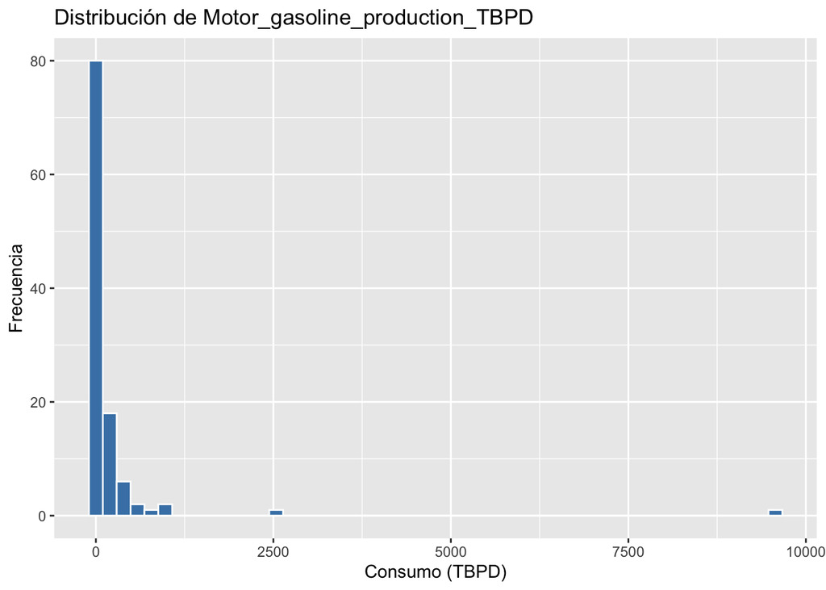

```r
ggplot(vars_interes, aes(x = Motor_gasoline_production_TBPD)) +
  geom_histogram(fill = "steelblue", color = "white", bins = 50) +
  labs(title = "Distribución de Motor_gasoline_production_TBPD",
       x = "Consumo (TBPD)",
       y = "Frecuencia")
```

Histograma de distribución Fossil_fuels_electricity_net_generation_BKWH

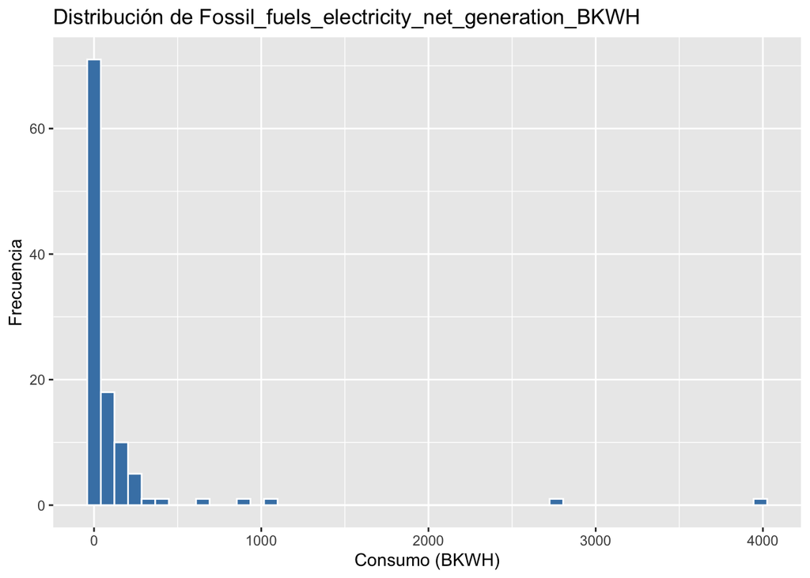

```r
ggplot(vars_interes, aes(x = Fossil_fuels_electricity_net_generation_BKWH)) +
  geom_histogram(fill = "steelblue", color = "white", bins = 50) +
  labs(title = "Distribución de Fossil_fuels_electricity_net_generation_BKWH",
       x = "Consumo (BKWH)",
       y = "Frecuencia")
```

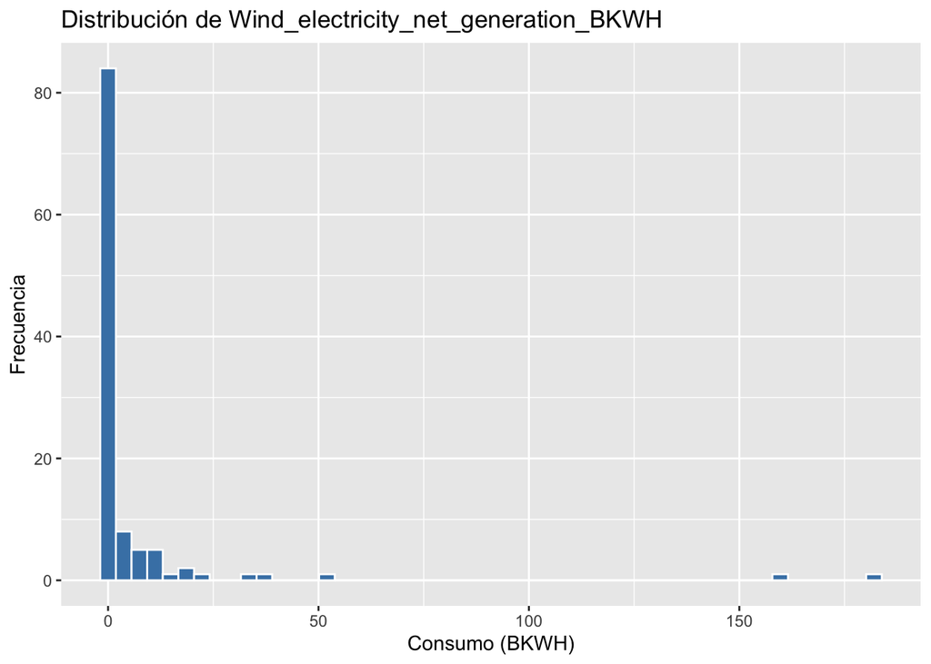

```r
ggplot(vars_interes, aes(x = Wind_electricity_net_generation_BKWH)) +
  geom_histogram(fill = "steelblue", color = "white", bins = 50) +
  labs(title = "Distribución de Wind_electricity_net_generation_BKWH",
       x = "Consumo (BKWH)",
       y = "Frecuencia")
```

#### Boxplots Boxplot Kerosene_consumption_TBPD

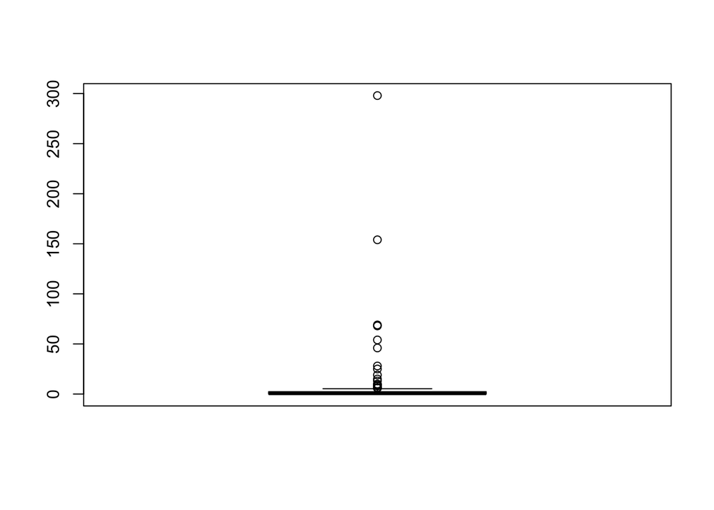

```r
boxplot(vars_interes$Kerosene_consumption_TBPD)
```

Boxplot Motor_gasoline_consumption_TBPD

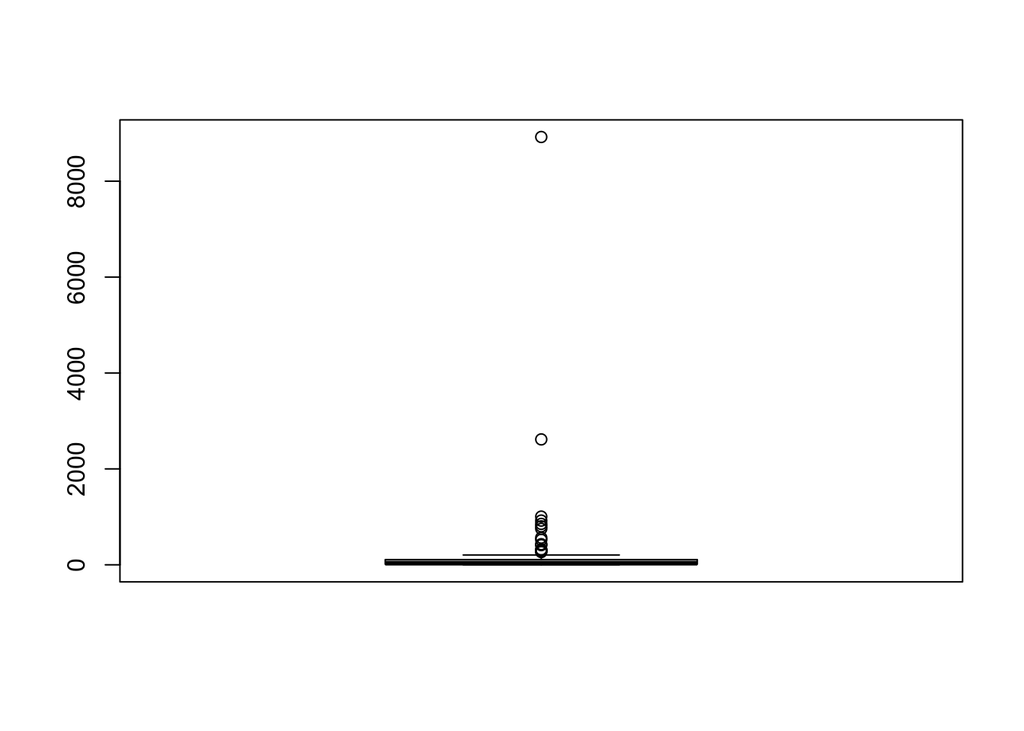

```r
boxplot(vars_interes$Motor_gasoline_consumption_TBPD)
```

Boxplot Motor_gasoline_production_TBPD

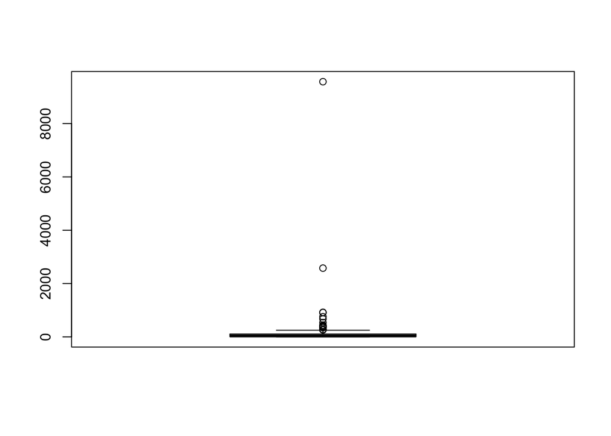

```r
boxplot(vars_interes$Motor_gasoline_production_TBPD)
```

Boxplot Fossil_fuels_electricity_net_generation_BKWH

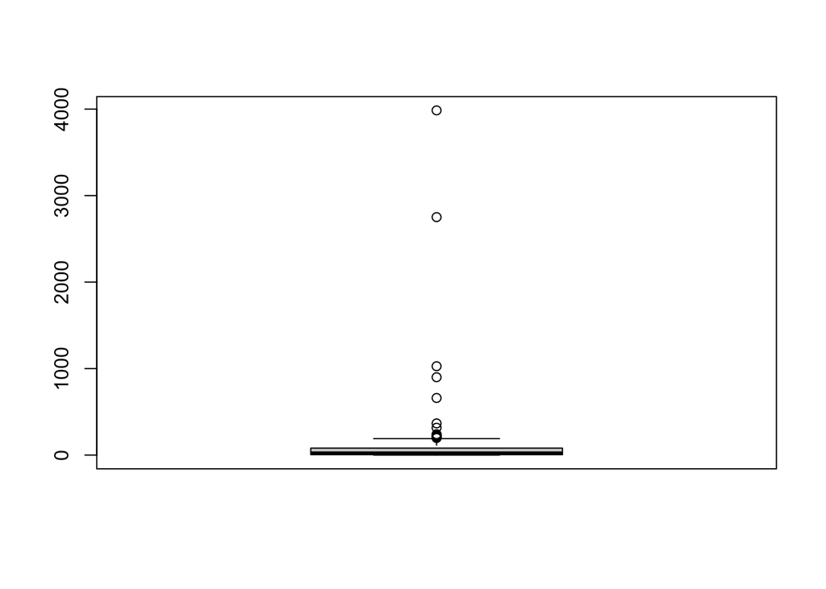

```r
boxplot(vars_interes$Fossil_fuels_electricity_net_generation_BKWH)
```

Boxplot Wind_electricity_net_generation_BKWH

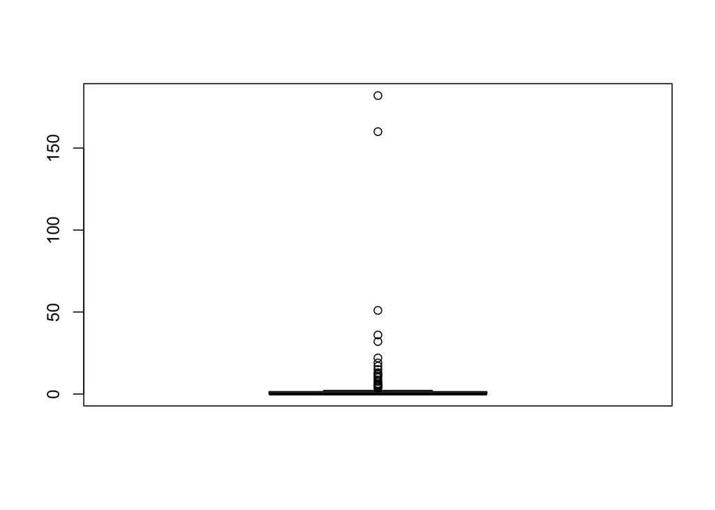

```r
boxplot(vars_interes$Wind_electricity_net_generation_BKWH)
```

### Análisis multivariado

La matriz de correlación indica la fuerza y dirección de las relaciones lineales entre las variables de un conjunto de datos.

```r
correlaciones <- cor(vars_interes, use = "complete.obs")
print(correlaciones)
```

```
##                                              Kerosene_consumption_TBPD
## Kerosene_consumption_TBPD                                    1.0000000
## Motor_gasoline_consumption_TBPD                              0.1232330
## Motor_gasoline_production_TBPD                               0.1286909
## Fossil_fuels_electricity_net_generation_BKWH                 0.2850277
## Wind_electricity_net_generation_BKWH                         0.1157454
##                                              Motor_gasoline_consumption_TBPD
## Kerosene_consumption_TBPD                                          0.1232330
## Motor_gasoline_consumption_TBPD                                    1.0000000
## Motor_gasoline_production_TBPD                                     0.9944726
## Fossil_fuels_electricity_net_generation_BKWH                       0.7561952
## Wind_electricity_net_generation_BKWH                               0.8550542
##                                              Motor_gasoline_production_TBPD
## Kerosene_consumption_TBPD                                         0.1286909
## Motor_gasoline_consumption_TBPD                                   0.9944726
## Motor_gasoline_production_TBPD                                    1.0000000
## Fossil_fuels_electricity_net_generation_BKWH                      0.7509407
## Wind_electricity_net_generation_BKWH                              0.8571400
##                                              Fossil_fuels_electricity_net_generation_BKWH
## Kerosene_consumption_TBPD                                                       0.2850277
## Motor_gasoline_consumption_TBPD                                                 0.7561952
## Motor_gasoline_production_TBPD                                                  0.7509407
## Fossil_fuels_electricity_net_generation_BKWH                                    1.0000000
## Wind_electricity_net_generation_BKWH                                            0.9070316
##                                              Wind_electricity_net_generation_BKWH
## Kerosene_consumption_TBPD                                               0.1157454
## Motor_gasoline_consumption_TBPD                                         0.8550542
## Motor_gasoline_production_TBPD                                          0.8571400
## Fossil_fuels_electricity_net_generation_BKWH                            0.9070316
## Wind_electricity_net_generation_BKWH                                    1.0000000
```

- Alta correlación entre Motor_gasoline_consumption_TBPD y Motor_gasoline_production_TBPD: 0.9945. Esto indica una relación casi perfecta. Los países que más gasolina producen también la consumen mucho.
- Alta correlación entre entre Fossil_fuels_electricity_net_generation_BKWH y Wind_electricity_net_generation_BKWH: 0.9070. Los países que generan más electricidad con fósiles también tienen alta generación eólica.
- Correlación fuerte entre Motor_gasoline_production_TBPD y Wind_electricity_net_generation_BKWH: 0.8571. Los paises con alta producción de gasolina, también tienen una alta generación neta de electricidad eólica.
- Kerosene_consumption_TBPD tiene correlaciones débiles con todas las demás (< 0.29).

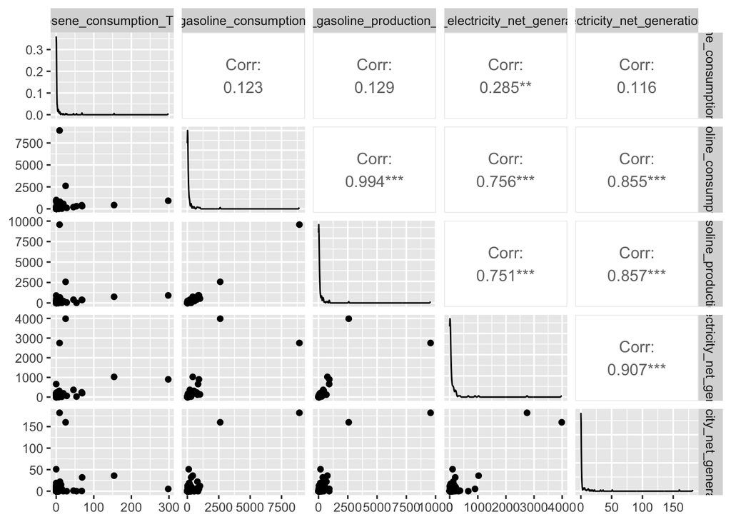

```r
ggpairs(vars_interes)
```

La mayoría de las variables tienen distribuciones sesgadas hacia valores bajos con algunos valores muy altos (ver diagramas de dispersión).

Esto sugiere que la mayoría de los países tienen baja producción o consumo, mientras que unos pocos tienen valores extremos.

### Pregunta 3 Ivan

$w_3=8$  
El conjunto de datos incluye 57 variables, analizarlas de forma individual podría representar un gasto computacional y de tiempo bastante agotador; por lo cuál una técnica de reducción de dimensionalidad sería ideal. Ejecute un ACP sobre estos datos, compare la contribución de las variables sobre el primer plano factorial de un ACP normado (escalado) y uno sin normalizar (sin escalar).

El conjunto de datos incluye 57 variables, analizarlas de forma individual podría representar un gasto computacional y de tiempo bastante agotador; por lo cual una técnica de reducción de dimensionalidad sería ideal. Ejecute un ACP sobre estos datos, compare la contribución de las variables sobre el primer plano factorial de un ACP normado (escalado) y uno sin normalizar (sin escalar).

```r
#carga de datos separados con sep=;
pais = read.table("/Users/aosoriom/Repos/MER_AEDatos/datasets/datos_taller_02.csv",sep=";",header = TRUE)

#se crea el data frame país
datos<-as.data.frame(pais)

#nueva variable y se le quita la 1ra columna
columnas_a_convertir <- names(datos)[-1]

#transformación de datos a numéricos str(Datos)
datos[columnas_a_convertir] <- lapply(datos[columnas_a_convertir], as.numeric)
# str(datos) --> se comenta para no sacar todos los datos, se debe quitar.

#selección de las 5 variables
select_data <- datos[, c("Refined_petroleum_products_consumption_TBPD", "Refined_petroleum_products_production_TBPD", "Electricity_exports_BKWH", "Electricity_imports_BKWH", "Electricity_installed_capacity_MK")]
summary(select_data)
```

```
##  Refined_petroleum_products_consumption_TBPD
##  Min.   :   15.0
##  1st Qu.:   71.5
##  Median :  202.0
##  Mean   :  811.4
##  3rd Qu.:  750.0
##  Max.   :19100.0
##  Refined_petroleum_products_production_TBPD Electricity_exports_BKWH
##  Min.   :    0.0                            Min.   : 0.000
##  1st Qu.:   39.5                            1st Qu.: 0.000
##  Median :  172.0                            Median : 0.600
##  Mean   :  777.3                            Mean   : 5.158
##  3rd Qu.:  555.0                            3rd Qu.: 5.550
##  Max.   :19653.0                            Max.   :75.000
##  Electricity_imports_BKWH Electricity_installed_capacity_MK
##  Min.   : 0.000           Min.   :   0.40
##  1st Qu.: 0.000           1st Qu.:   3.50
##  Median : 0.700           Median :  11.00
##  Mean   : 5.671           Mean   :  51.63
##  3rd Qu.: 7.550           3rd Qu.:  33.00
##  Max.   :67.000           Max.   :1380.00
```

```r
#se excluye la primera columna
columnas_numericas <- names(datos)[-1]

#se aplica pca a datos normalizados o escalados

#"prcom()p" es la forma rápida de implementar un PCA sobre un conjunto de datos, es necesaria la biblioteca stats, center y SCALE TRUE corresponden a las medias y desv estándar antes de aplicar el PCA
pca_normalizado <- prcomp(datos[, columnas_numericas], center = TRUE, scale = TRUE)

#se aplica pca a datos sin normalizar
pca_sin_normalizar <- prcomp(datos[, columnas_numericas], center = FALSE, scale = FALSE)

#se comparan las contirbuciones de las variables seleccionadas
contribucion_normalizado <- pca_normalizado$sdev^2
contribucion_sin_normalizar <- pca_sin_normalizar$sdev^2

#creación de tabla de datos para luego ver las contribuciones
contribuciones_df <- data.frame(
  Contribucion_Normalizado = contribucion_normalizado,
  Contribucion_Sin_Normalizar = contribucion_sin_normalizar)
```

### Pregunta 5 Diego

$w_5=8$  
Analice la representación de las variables originales sobre las dos primeras componentes en el primer plano factorial. ¿Que conclusiones podemos sacar de este análisis?

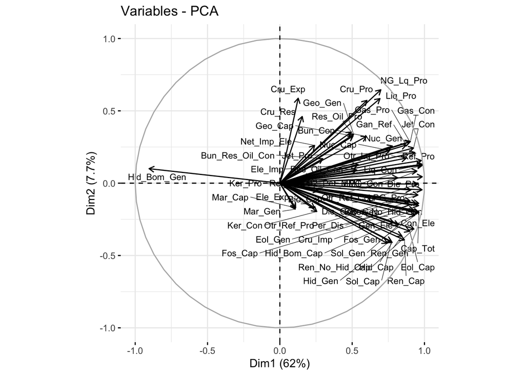

```r
#agrupa los datos por componentes principales escalados y los guarda en la variable asignada acp_c (para reducir el tamaño del nombre de las variables se utiliza IA)
# La sintaxis [, -1] selecciona todas las filas (espacio antes de la coma)
# y todas las columnas excepto la columna en el índice 1 (el -1 después de la coma)
datos_rec <- read.table("/Users/aosoriom/Repos/MER_AEDatos/datasets/datos_taller_02_rec.csv",sep=";",header = TRUE)
datos_solo_numericos <- datos_rec[, -1]
acp_c <-prcomp(datos_solo_numericos, scale = TRUE)

fviz_pca_var(acp_c,axes=c(1,2),repel=TRUE, labelsize=3, arrowsize=0.5, arrowwidth=0.5)
```

En el siguiente diagrama fasorial se grafican los 2 componentes principales, la misma es un poco difusa porque se están graficando las 57 variables.

### Pregunta 6 Daniel

$w_6=10$  
Ahora examine con detenimiento el mapa de individuos sobre los planos factoriales que conforman las componentes (1,2) y (2,3). ¿Qué conclusiones puede sacar según la cercanía de algunas UE?

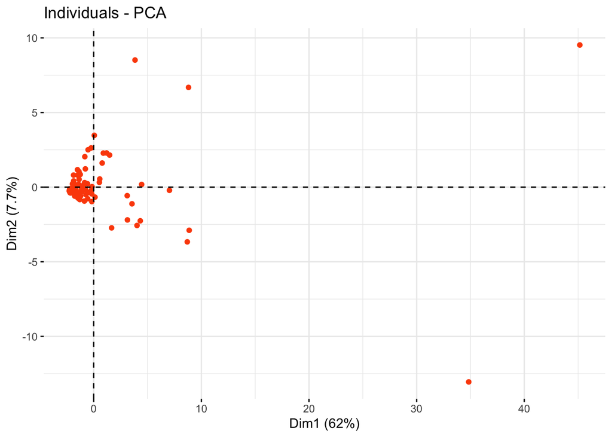

```r
res.pca <- PCA(datos[,-1], graph = FALSE)
fviz_pca_ind(res.pca, geom.ind = "point",
             col.ind = "#FC4E07",
             axes = c(1, 2),
             pointsize = 1.5)
```

Dim2 (7.7%):

- Su contribución parece marginal, por lo que el análisis se centra en Dim1 (62%).

Distribución de Países

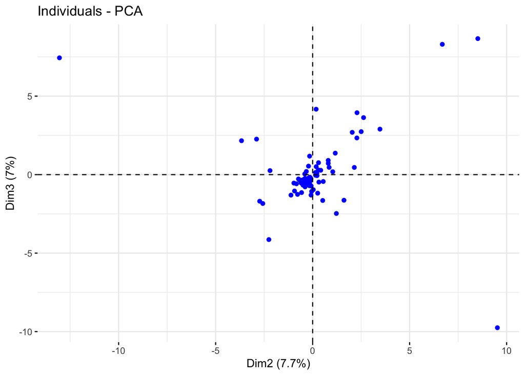

```r
fviz_pca_ind(res.pca, geom.ind = "point",
             col.ind = "blue",
             axes = c(2, 3),
             pointsize = 1.5)
```

Dim3 (7%) y Dim2 (7.7%):

Ambos componentes explican una proporción baja de varianza total (14.7% combinada). Esto sugiere que:

- La estructura subyacente de los datos es alta-dimensional (muchas variables influyentes no capturadas en estos ejes).

Distribución de Países

### Pregunta 7 Ivan

$w_7=10$  
Como hemos observado en clase, el ACP es una técnica bastante sensible a datos atípicos, ejecute nuevamente el ACP retirando del conjunto de datos a Estados Unidos, China, Arabia Saudi y Rusia. ¿En que cambia el ACP al excluir estos países?. ¿Se perciben clusters de países con mayor claridad?. Calcule únicamente el ACP normado.

```r
#se retiran los países propuestos
retirados <- c("UnitedStates", "China", "SaudiArabia", "Russia")

#creación de la nueva tabla de datos que ya no tienen los países retirados
paises_filtrados <- datos[!datos$Country %in% retirados, ]
columnas_numericas <- names(paises_filtrados)[-1]

pca_normalizado <- prcomp(paises_filtrados[, columnas_numericas], center = TRUE, scale = TRUE)
pca_sin_normalizar <- prcomp(paises_filtrados[, columnas_numericas], center = FALSE, scale = FALSE)

contribucion_normalizado <- pca_normalizado$sdev^2
contribucion_sin_normalizar <- pca_sin_normalizar$sdev^2

contribuciones_df <- data.frame(
  Contribucion_Normalizado = contribucion_normalizado,
  Contribucion_Sin_Normalizar = contribucion_sin_normalizar
)

varianza_explicada <- pca_normalizado$sdev^2

varianza_acumulada <- cumsum(varianza_explicada) / sum(varianza_explicada)

head(contribuciones_df)
```

```
##   Contribucion_Normalizado Contribucion_Sin_Normalizar
## 1                27.899628                  4098283.84
## 2                 5.838730                  1445037.17
## 3                 4.620440                    86544.80
## 4                 3.775331                    41993.07
## 5                 2.821063                    26544.39
## 6                 2.228604                    14081.66
```

Los países retirados presentan datos atípicos ya que son grandes consumidores de recursos energéticos como la electricidad o el petróleo y por otra parte, también se tienen grandes productores de aquellos recursos.

Lo anterior debido a que los países retirados presentaban datos altos si se comparaban con otros, lo que hacía que la escala de datos fuera mucho mayor. Al ser retirados estos países con datos atípicos, contribuye a buscar más eficazmente países con comportamientos más comunes entre sí y permite sean agrupados de o subdivididos de manera geográfica, por ejemplo.

## Clustering

Los puntos 8 a 11 se realizarán excluyendo de la base de datos los países atípicos mencionados en el punto 7 (es decir, retirando ‘UnitedStates’,‘China’,‘SaudiArabia’,‘Russia’).

### Pregunta 8 Zahira

$w_8=8$  
De acuerdo a lo aprendido en la clase de agrupamiento, utilice el primer plano factorial para determinar de manera aproximada el número de grupos en el análisis. ¿Cuántos clusters espera que existan en el conjunto de datos?

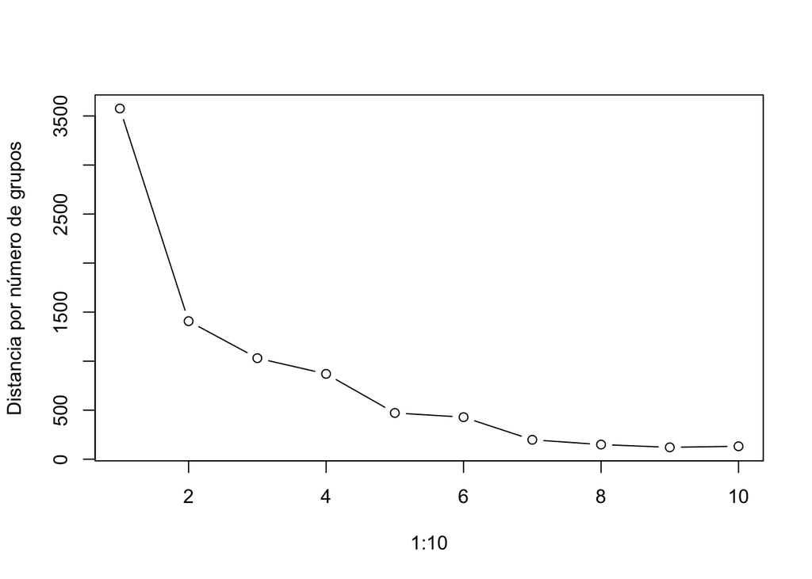

```r
PrimerasComponentes <- pca_normalizado$x[, c(1, 2)] #Seleccion de la ubicación de cada país en las dos componentes principales
distancia_total <- numeric(10)  # Crear vector de longitud 10

for (i in 1:10)
  {
    kmeans_model <- kmeans(PrimerasComponentes, centers = i) #agrupar los datos ubicados en el plano en i cantidad de grupos
    distancia_total[i] <- kmeans_model$tot.withinss #sumar la distancia total de la agrupación i
  }
  plot(1:10,distancia_total,ylab="Distancia por número de grupos", xlab = '1:10', type='b')
```

### Pregunta 10 Diego

$w_{10}=12$  
Determine mediante k-means y aglomeración jerárquica (usando enlace promedio) la clasificación en grupos para los países de estudio. Considere todas las variables de estudio ¿son diferentes los resultados de los dos análisis cluster?

```r
set.seed(100)
kmeans_m <- kmeans(pca_normalizado$x, centers = 4)# aplicar K-means con 4 clusters
clusters <- kmeans_m$cluster

 # mostrar tabla con los 4 clusters
 table(clusters)
```

```
## clusters
##  1  2  3  4
##  8 10  2 87
```

```r
# aplicar metodo de aglomeracion promedio
d_aglomerados <- hclust(dist(pca_normalizado$x), method = "average")

#lleva el arbol jerarquico a 4 grupos para poder comparar con el resultado de kmeans
clusters_aglomerados <- cutree(d_aglomerados, k = 4)

#resultados de de los 4 grupos aglomerados
table(clusters_aglomerados)
```

```
## clusters_aglomerados
##   1   2   3   4
## 101   2   2   2
```

### Pregunta 11 Zahira

$w_{11}=12$  
Grafique mediante boxplot la distribución de las 5 variables seleccionadas en el punto 2 diferenciando por los grupos encontrados mediante k-means (es decir, obtenga un boxplot por variable y por grupo: si por ejemplo k-means indica un total de 3 grupos, realice 3 boxplots, uno por grupo, para cada una de las 5 variables). ¿Observa diferencias importantes entre las distribuciones por grupos de la misma variable?

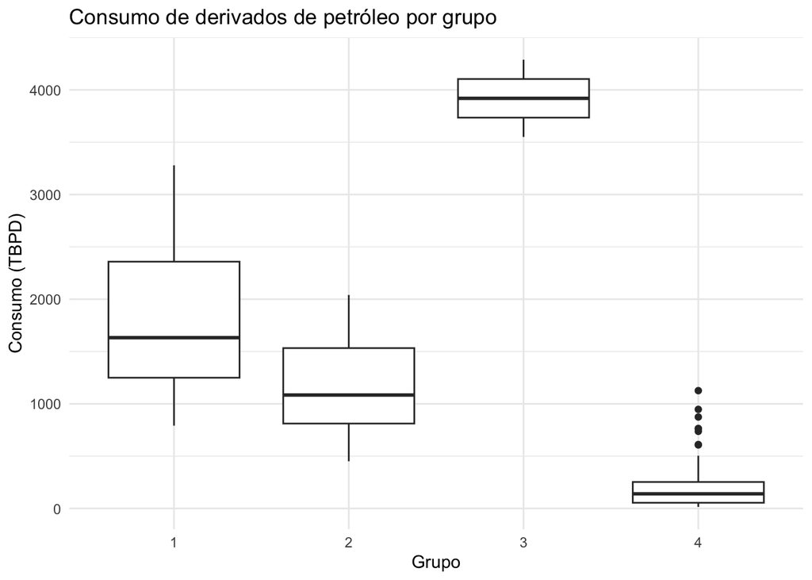

```r
Variables_Escogidas = paises_filtrados[, c("Country" ,"Refined_petroleum_products_consumption_TBPD", "Refined_petroleum_products_production_TBPD", "Electricity_exports_BKWH", "Electricity_imports_BKWH", "Electricity_installed_capacity_MK")]
Variables_Escogidas$Grupo <- clusters # agregar al set de datos una columna con el grupo

# boxplot de Refined_petroleum_products_consumption_TBPD
ggplot(Variables_Escogidas, aes(x = factor(Grupo), y = Refined_petroleum_products_consumption_TBPD)) +
  geom_boxplot() +
  theme_minimal() +
  labs(
    title = "Consumo de derivados de petróleo por grupo",
    x = "Grupo",
    y = "Consumo (TBPD)" )
```

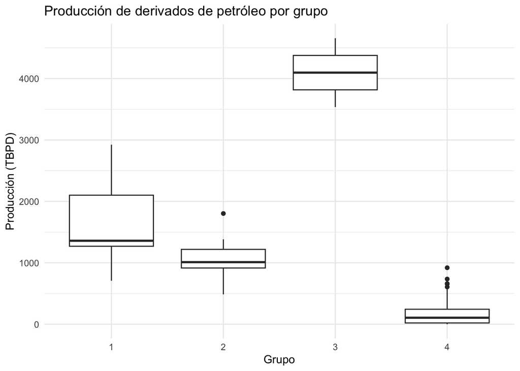

```r
# boxplot de Refined_petroleum_products_production_TBPD
ggplot(Variables_Escogidas, aes(x = factor(Grupo), y = Refined_petroleum_products_production_TBPD)) +
  geom_boxplot() +
  theme_minimal() +
  labs(
    title = "Producción de derivados de petróleo por grupo",
    x = "Grupo",
    y = "Producción (TBPD)" )
```

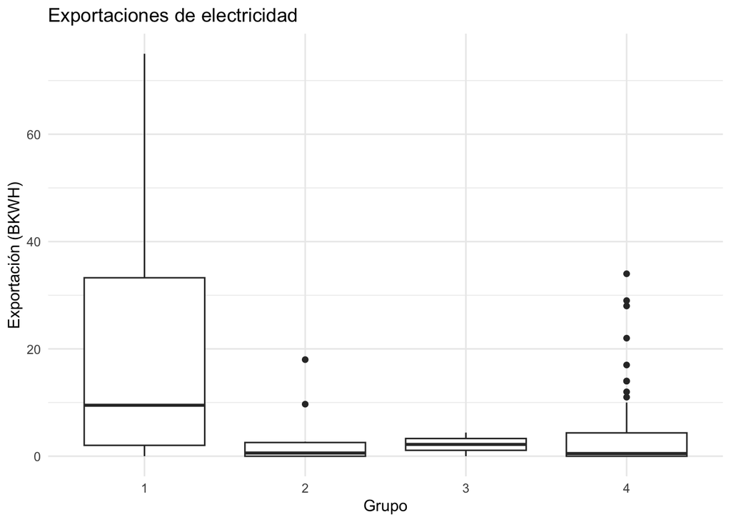

```r
# boxplot de Electricity_exports_BKWH
ggplot(Variables_Escogidas, aes(x = factor(Grupo), y = Electricity_exports_BKWH)) +
  geom_boxplot() +
  theme_minimal() +
  labs(
    title = "Exportaciones de electricidad",
    x = "Grupo",
    y = "Exportación (BKWH)")
```

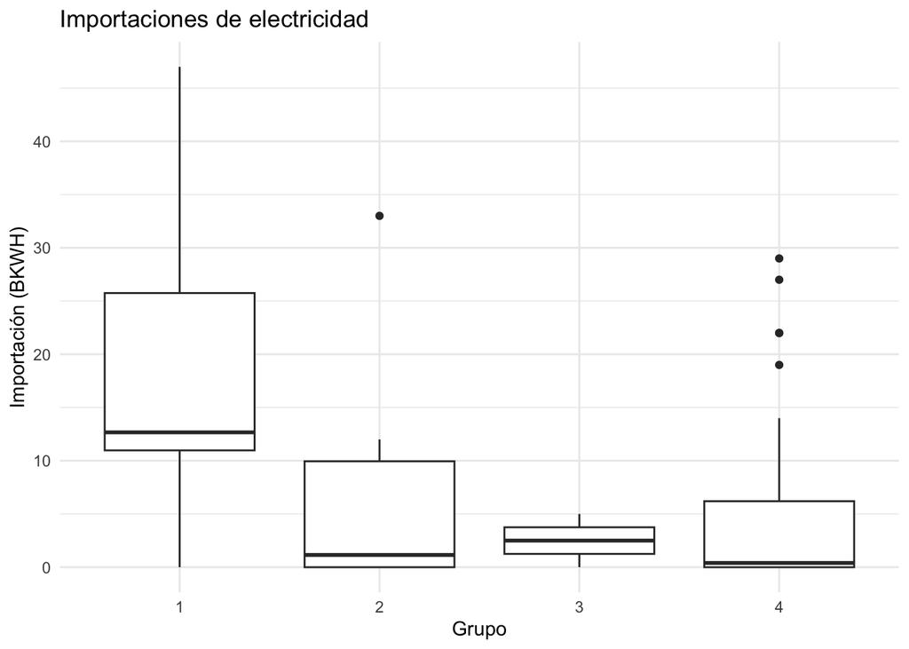

```r
# boxplot de Electricity_imports_BKWH
ggplot(Variables_Escogidas, aes(x = factor(Grupo), y = Electricity_imports_BKWH)) +
  geom_boxplot() +
  theme_minimal() +
  labs(
    title = "Importaciones de electricidad",
    x = "Grupo",
    y = "Importación (BKWH)")
```

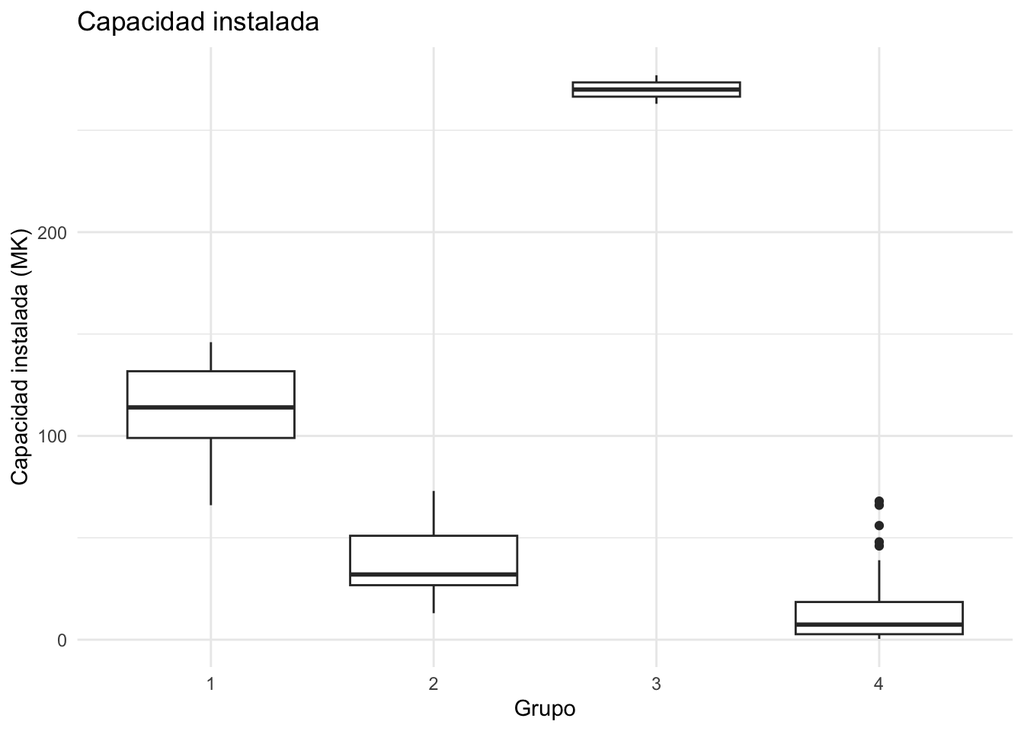

```r
# boxplot de Electricity_installed_capacity_MK
ggplot(Variables_Escogidas, aes(x = factor(Grupo), y = Electricity_installed_capacity_MK)) +
  geom_boxplot() +
  theme_minimal() +
  labs(
    title = "Capacidad instalada",
    x = "Grupo",
    y = "Capacidad instalada (MK)")
```

## Referencias

1. [Introduction to R markdown](https://rmarkdown.rstudio.com/articles_intro.html)
2. MarkDown Guide - [Basic Syntax](https://www.markdownguide.org/basic-syntax/)
3. [Data Visualization CheatSheet](https://github.com/rstudio/cheatsheets/blob/main/data-visualization.pdf)
4. [Repositorio](https://github.com/aosoriom7/MER_AED_2025I) del Taller en Github
5. [Pagina](https://aosoriom7.github.io/MER_AED_2025I/scripts/02.html) web del taller en Gihub Pages